# Layout Customization

The package offers a suite of `align_*` functions designed to give you precise control over plot layout. These functions enable you to reorder the observations or partition the observations into multiple groups.

Currently, there are four key `align_*` functions available for layout customization:

- **`align_group`**: Group and align plots based on categorical factors.
- **`align_order`**: Reorder layout observations based on statistical weights or allows for manual reordering based on user-defined ordering index.
- **`align_kmeans`**: Group observations by k-means clustering results.
- **`align_dendro`**: Align plots according to hierarchical clustering or dendrograms.

```r
library(ggalign)
```

```r
set.seed(123)
small_mat <- matrix(rnorm(81), nrow = 9)
rownames(small_mat) <- paste0("row", seq_len(nrow(small_mat)))
colnames(small_mat) <- paste0("column", seq_len(ncol(small_mat)))
```

## `align_group`

The `align_group()` function allows you to group rows/columns into separate panels. It doesn’t add any plot area.

```
#> → heatmap built with `geom_tile()`
```

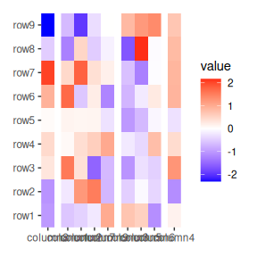

```r
ggheatmap(small_mat) +
    anno_top() +
    align_group(sample(letters[1:4], ncol(small_mat), replace = TRUE))
```

By default, the facet strip text is removed. You can override this behavior with `theme(strip.text = element_text())`. Since `align_group()` does not create a new plot, the panel title can only be added to the heatmap plot.

```
#> → heatmap built with `geom_tile()`
```

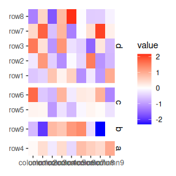

```r
ggheatmap(small_mat) +
    theme(strip.text = element_text()) +
    anno_left() +
    align_group(sample(letters[1:4], nrow(small_mat), replace = TRUE))
```

## `align_order`

The `align_order()` function order the rows/columns based on the summary weights, Like `align_group()`, it doesn’t add a plot area.

Here, we order the rows based on the means.

```
#> → heatmap built with `geom_tile()`
```

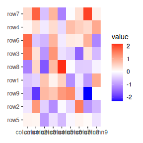

```r
ggheatmap(small_mat) +
    anno_left() +
    align_order(rowMeans)
```

In addition, we can provide the ordering integer index directly in the `order` argument.

```r
my_order <- sample(nrow(small_mat))
print(rownames(small_mat)[my_order])
```

```
#> [1] "row3" "row1" "row7" "row6" "row2" "row8" "row9" "row5" "row4"
```

```
#> → heatmap built with `geom_tile()`
```

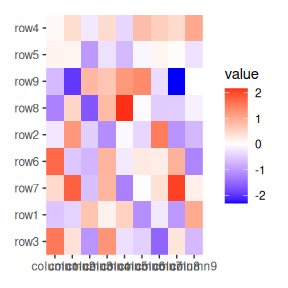

```r
ggheatmap(small_mat) +
    anno_left() +
    align_order(my_order)
```

We can also provide the ordering character index.

```
#> → heatmap built with `geom_tile()`
```

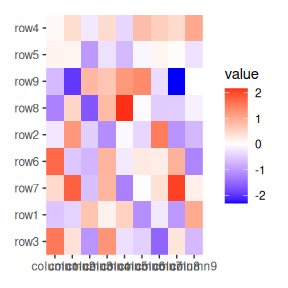

```r
ggheatmap(small_mat) +
    anno_left() +
    align_order(rownames(small_mat)[my_order])
```

By default, `align_order()` reorders the rows or columns in ascending order of the summary function’s output (from bottom to top for rows, or from left to right for columns). To reverse this order, you can set `reverse = TRUE`:

```
#> → heatmap built with `geom_tile()`
```

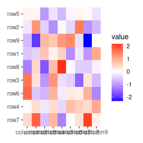

```r
ggheatmap(small_mat) +
    anno_left() +
    align_order(rowMeans, reverse = TRUE)
```

Some `align_*` functions accept a `data` argument. This can be a matrix, a data frame, or even a simple vector. The `data` argument can also accept a function (purrr-like lambda syntax is supported), which will be applied to the layout data. It is important to note that all `align_*` functions consider the `rows` as the observations. It means the `NROW(data)` must return the same number with the observations in axis used for alignment.

- `quad_layout()`/`ggheatmap()`: for column annotation, the `layout` data will be transposed before using (If data is a `function`, it will be applied with the transposed matrix). This is necessary because column annotation uses heatmap columns as observations, but we need rows.
- `stack_layout()`/`ggstack()`: the `layout` data will be used as it is since we place all plots along a single axis.

Even for top and bottom annotations, you can use `rowMeans()` to calculate the mean value across all columns.

```
#> → heatmap built with `geom_tile()`
```

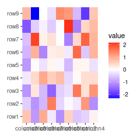

```r
ggheatmap(small_mat) +
    anno_top() +
    align_order(rowMeans)
```

## `align_kmeans`

The `align_kmeans()` function groups heatmap rows or columns based on k-means clustering. Like the previous functions, it does not add a plot area.

```
#> → heatmap built with `geom_tile()`
```

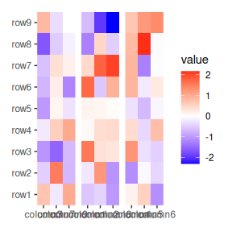

```r
ggheatmap(small_mat) +
    anno_top() +
    align_kmeans(3L)
```

Note that all `align_*` functions which define groups must not break the previous established groups. This means the new groups must nest in the old groups, in this way, usually they cannot be used if groups already exist.

```r
ggheatmap(small_mat) +
    anno_top() +
    align_group(sample(letters[1:4], ncol(small_mat), replace = TRUE)) +
    align_kmeans(3L)
```

```
#> Error in `align_kmeans()`:
#> ! `align_kmeans()` disrupt the previously established panel groups of
#>   the layout x-axis
```

```r
ggheatmap(small_mat) +
    anno_top() +
    align_kmeans(3L) +
    align_group(sample(letters[1:4], ncol(small_mat), replace = TRUE))
```

```
#> Error in `align_group()`:
#> ! `align_group()` disrupt the previously established panel groups of the
#>   layout x-axis
```

## align_dendro

The `align_dendro()` function adds a dendrogram to the layout and can also reorder or split the layout based on hierarchical clustering. This is particularly useful for working with heatmap plots.

```
#> → heatmap built with `geom_tile()`
```

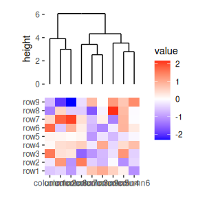

```r
ggheatmap(small_mat) +
    anno_top() +
    align_dendro()
```

Hierarchical clustering is performed in two steps: calculate the distance matrix and apply clustering. You can use the `distance` and `method` argument to control the dendrogram builind process.

There are two ways to specify `distance` metric for clustering:

- specify `distance` as a pre-defined option. The valid values are the supported methods in `dist()` function and coorelation coefficient `"pearson"`, `"spearman"` and `"kendall"`. The correlation distance is defined as `1 - cor(x, y, method = distance)`.
- a self-defined function which calculates distance from a matrix. The function should only contain one argument. Please note for clustering on columns, the matrix will be transposed automatically.

```
#> → heatmap built with `geom_tile()`
```

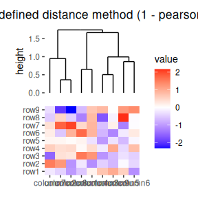

```r
ggheatmap(small_mat) +
    anno_top() +
    align_dendro(distance = "pearson") +
    patch_titles(top = "pre-defined distance method (1 - pearson)")
```

```
#> → heatmap built with `geom_tile()`
```

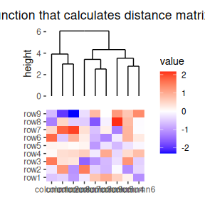

```r
ggheatmap(small_mat) +
    anno_top() +
    align_dendro(distance = function(m) dist(m)) +
    patch_titles(top = "a function that calculates distance matrix")
```

Method to perform hierarchical clustering can be specified by `method`. Possible methods are those supported in `hclust()` function. And you can also provide a self-defined function, which accepts the distance object and return a `hclust` object.

```
#> → heatmap built with `geom_tile()`
```

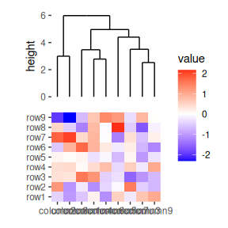

```r
ggheatmap(small_mat) +
    anno_top() +
    align_dendro(method = "ward.D2")
```

The dendrogram can also be used to cut the columns/rows into groups. You can specify `k` or `h`, which work similarly to `cutree()`:

```
#> → heatmap built with `geom_tile()`
```

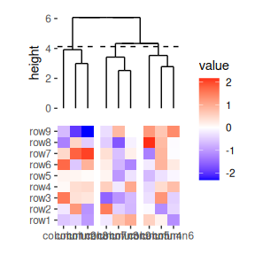

```r
ggheatmap(small_mat) +
    anno_top() +
    align_dendro(k = 3L)
```

In contrast to `align_group()`, `align_kmeans()`, and `align_order()`, `align_dendro()` is capable of drawing plot components. So it has a default `set_context` value of `TRUE`, meaning it will set the active context of the annotation stack layout. In this way, we can add any ggplot elements to this plot area.

```
#> → heatmap built with `geom_tile()`
```

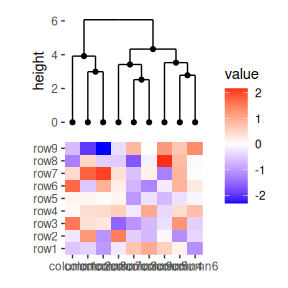

```r
ggheatmap(small_mat) +
    anno_top() +
    align_dendro() +
    geom_point(aes(y = y))
```

The `align_dendro()` function creates default `node` data for the ggplot. See `ggplot2 specification` in `?align_dendro` for details. Additionally, `edge` data is added to the `ggplote::geom_segment()` layer directly, used to draw the dendrogram tree. One useful variable in both `node` and `edge` data is the `branch` column, corresponding to the `cutree` result:

```
#> → heatmap built with `geom_tile()`
```

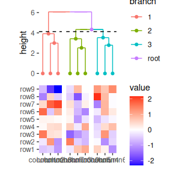

```r
ggheatmap(small_mat) +
    anno_top() +
    align_dendro(aes(color = branch), k = 3) +
    geom_point(aes(color = branch, y = y))
```

You can reorder the dendrogram based on the mean values of the observations by setting `reorder_dendrogram = TRUE`.

```
#> → heatmap built with `geom_tile()`
#> → heatmap built with `geom_tile()`
```

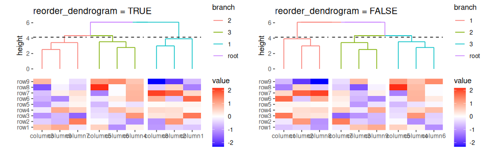

```r
h1 <- ggheatmap(small_mat) +
    anno_top() +
    align_dendro(aes(color = branch), k = 3, reorder_dendrogram = TRUE) +
    ggtitle("reorder_dendrogram = TRUE")
h2 <- ggheatmap(small_mat) +
    anno_top() +
    align_dendro(aes(color = branch), k = 3) +
    ggtitle("reorder_dendrogram = FALSE")
align_plots(h1, h2)
```

`align_dendro()` can also perform clustering between groups, meaning it can be used even if there are existing groups present in the layout, in this way, you cannot specify `k` or `h`:

```
#> → heatmap built with `geom_tile()`
```

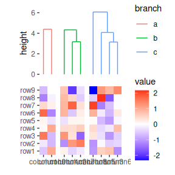

```r
set.seed(3L)
column_groups <- sample(letters[1:3], ncol(small_mat), replace = TRUE)
ggheatmap(small_mat) +
    anno_top() +
    align_group(column_groups) +
    align_dendro(aes(color = branch))
```

You can reorder the groups by setting `reorder_group = TRUE`.

```
#> → heatmap built with `geom_tile()`
```

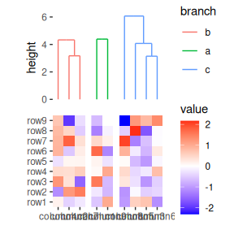

```r
ggheatmap(small_mat) +
    anno_top() +
    align_group(column_groups) +
    align_dendro(aes(color = branch), reorder_group = TRUE)
```

You can merge the sub-tree in each group by settting `merge_dendrogram = TRUE`.

```
#> → heatmap built with `geom_tile()`
```

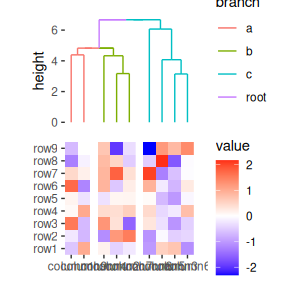

```r
ggheatmap(small_mat) +
    anno_top() +
    align_group(column_groups) +
    align_dendro(aes(color = branch), merge_dendrogram = TRUE)
```

You can reorder the dendrogram and merge simutaneously.

```
#> → heatmap built with `geom_tile()`
```

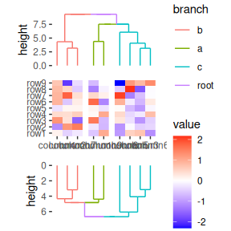

```r
ggheatmap(small_mat) +
    anno_top() +
    align_group(column_groups) +
    align_dendro(aes(color = branch),
        reorder_group = TRUE,
        merge_dendrogram = TRUE
    ) +
    anno_bottom() +
    align_dendro(aes(color = branch),
        reorder_group = FALSE,
        merge_dendrogram = TRUE
    )
```

If you specify `k` or `h`, this will always turn off sub-clustering. The same principle applies to `align_dendro()`, where new groups must be nested within the previously established groups.

```r
ggheatmap(small_mat) +
    anno_top() +
    align_group(column_groups) +
    align_dendro(k = 2L)
```

```
#> Error in `align_dendro()`:
#> ! `align_dendro()` disrupt the previously established panel groups of
#>   the layout x-axis
```